# DoRothEA regulons.

Pau Badia i Mompel

Institute for Computational Biomedicine, Heidelberg University

pau.badia@uni-heidelberg.de

27 February 2024

#### Package

dorothea 1.14.1

# 1 Introduction

DoRothEA is a gene regulatory network (GRN) containing signed transcription factor (TF) - target gene interactions. DoRothEA regulons, the collection of TFs and their transcriptional targets, were curated and collected from different types of evidence for both human and mouse.

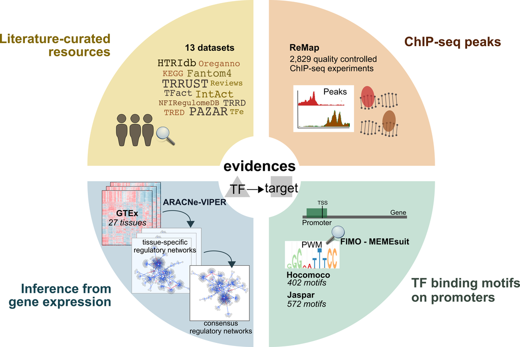

For each TF-target interaction we assigned a confidence level based on the number of supporting evidence. The confidence assignment comprises five levels, ranging from A (highest confidence) to E (lowest confidence). Interactions that are supported by all four lines of evidence, manually curated by experts in specific reviews, or supported both in at least two curated resources are considered to be highly reliable and were assigned an A level. Level B-D are reserved for curated and/or ChIP-seq interactions with different levels of additional evidence. Finally, E level is used for interactions that are uniquely supported by computational predictions. To provide the most confident regulon for each TF, we aggregated the TF-target interactions with the highest possible confidence score that resulted in a regulon size equal to or greater than ten targets. The final confidence level assigned to the TF regulon is the lowest confidence score of its component targets.

# 2 Activity estimation

DoRothEA regulons can be coupled with any statistical method to infer TF activities from bulk or single-cell transcriptomics. In this vignette we just show how to access these regulons and some of their properties. To infer TF activities, please check out [decoupleR](https://doi.org/10.1093/bioadv/vbac016), available in [R](https://saezlab.github.io/decoupleR/) or [python](https://github.com/saezlab/decoupler-py).

# 3 Load

First we load the necessary packages:

```r
library(dorothea)
library(decoupleR)
library(ggplot2)
library(dplyr)
```

Here is how to retrieve all regulons from human:

```r
net <- decoupleR::get_dorothea(levels = c('A', 'B', 'C', 'D'))
head(net)
```

```
#> # A tibble: 6 × 4
#>   source confidence target   mor
#>   <chr>  <chr>      <chr>  <dbl>
#> 1 MYC    A          TERT    1
#> 2 JUN    D          SMAD3   0.25
#> 3 SMAD3  A          JUN     1
#> 4 JUN    D          SMAD4   0.25
#> 5 SMAD4  A          JUN     1
#> 6 RELA   D          FAS     0.25
```

# 4 Exploration

We can observe the total number of genes per TF:

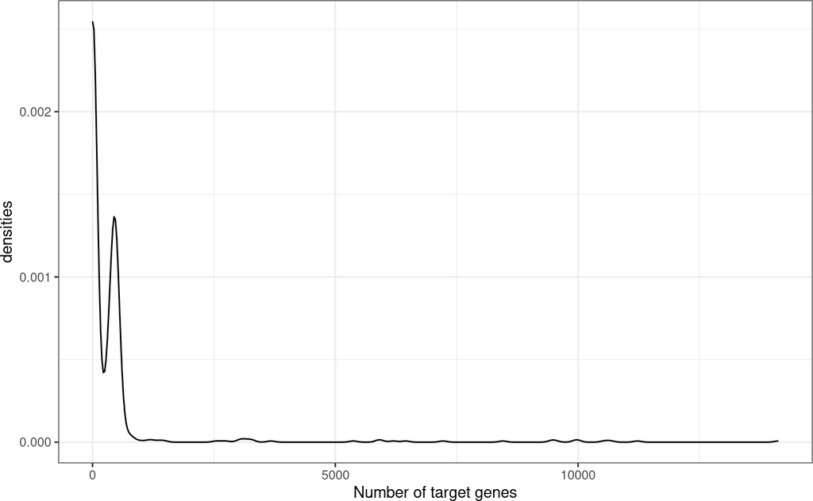

```r
n_genes <- net %>%
  group_by(source) %>%
  summarize(n = n())

ggplot(data=n_genes, aes(x=n)) +
  geom_density() +
  theme(text = element_text(size=12)) +
  xlab('Number of target genes') +
  ylab('densities') +
  theme_bw() +
  theme(legend.position = "none")
```

The majority of TFs have around 20 target genes, but there are some that reach more than 1000.

Additionally, we can visualize how many edges each confidence level adds:

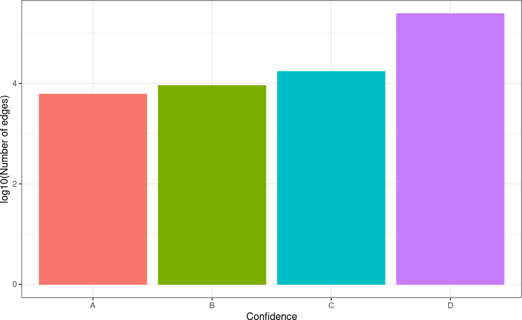

```r
n_edges <- net %>%
  group_by(confidence) %>%
  summarize(n = n())

ggplot(data=n_edges, aes(x=confidence, y=log10(n), color=confidence, fill=confidence)) +
  geom_bar(stat="identity") +
  theme(text = element_text(size=12)) +
  xlab('Confidence') +
  ylab('log10(Number of edges)') +
  theme_bw() +
  theme(legend.position = "none")
```

We can also check how many TFs are repressors, TFs with most of their edges with negative mode of regulation (`mor`), and how many are activators, TFs with most of their edges with positive `mor`:

```r
prop <- net %>%
  mutate(mor = case_when(mor < 0 ~ -1, mor > 0 ~ 1)) %>%
  group_by(source, mor) %>%
  summarize(n = n()) %>%
  mutate(freq = n / sum(n)) %>%
  filter(mor == 1)
```

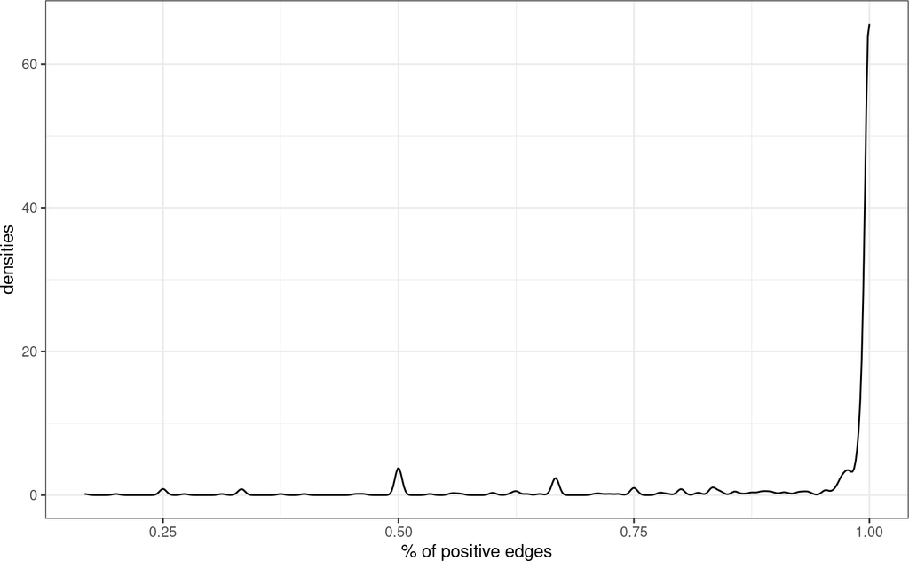

```r
ggplot(data=prop, aes(x=freq)) +
  geom_density() +
  theme(text = element_text(size=12)) +
  xlab('% of positive edges') +
  ylab('densities') +
  theme_bw() +
  theme(legend.position = "none")
```

Most TFs in DoRothEA are activators, but there are also some of them that are repressors.

# 5 CollecTRI

Recently, we have released a new literature based GRN with increased coverage and better performance at identifying perturbed TFs, called CollecTRI. We encourage users to use CollecTRI instead of DoRothEA. Vignettes on how to obtain activities are available at the [decoupleR package](https://saezlab.github.io/decoupleR/).

Here’s how to access it. The argument `split_complexes` keeps complexes or splits them into subunits, by default we recommend to keep complexes together.

```r
net <- decoupleR::get_collectri(split_complexes = FALSE)
head(net)
```

```
#> # A tibble: 6 × 3
#>   source target   mor
#>   <chr>  <chr>  <dbl>
#> 1 MYC    TERT       1
#> 2 SPI1   BGLAP      1
#> 3 SMAD3  JUN        1
#> 4 SMAD4  JUN        1
#> 5 STAT5A IL2        1
#> 6 STAT5B IL2        1
```

We can observe the total number of genes per TF:

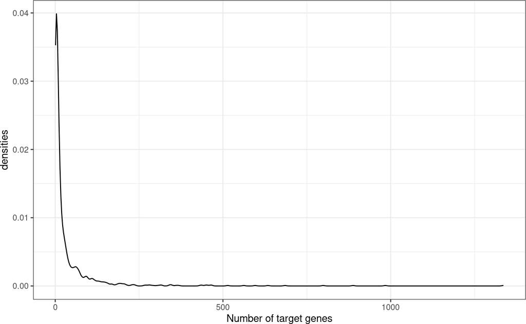

```r
n_genes <- net %>%
  group_by(source) %>%
  summarize(n = n())

ggplot(data=n_genes, aes(x=n)) +
  geom_density() +
  theme(text = element_text(size=12)) +
  xlab('Number of target genes') +
  ylab('densities') +
  theme_bw() +
  theme(legend.position = "none")
```

Similarly to DoRothEA, the majority of TFsin CollecTRI have around 20 target genes, but there are some that reach more than 1000.

We can also check how many TFs are repressors, TFs with most of their edges with negative mode of regulation (`mor`), and how many are activators, TFs with most of their edges with positive `mor`:

```r
prop <- net %>%
  mutate(mor = case_when(mor < 0 ~ -1, mor > 0 ~ 1)) %>%
  group_by(source, mor) %>%
  summarize(n = n()) %>%
  mutate(freq = n / sum(n)) %>%
  filter(mor == 1)
```

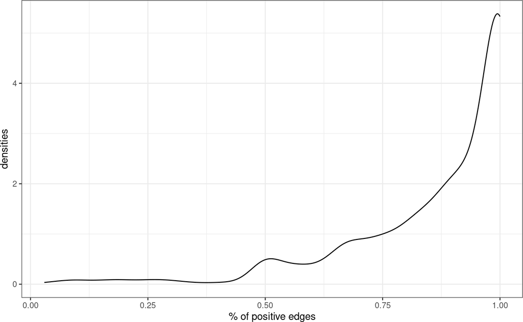

```r
ggplot(data=prop, aes(x=freq)) +
  geom_density() +
  theme(text = element_text(size=12)) +
  xlab('% of positive edges') +
  ylab('densities') +
  theme_bw() +
  theme(legend.position = "none")
```

As seen in DoRothEA, Most TFs in CollecTRI are also activators.